# MohameBassem: Traffic Data Analysis

```r
library(ggplot2)
library(tidyr)
library(dplyr)
library(knitr)
library(stringr)
library(knitr)
```

## First Look on the data

First of all let’s read the data

```r
data <- read.csv("../traffic-data.csv")
```

Now let’s see some stats about the data

```r
data %>% dim
```

```
## [1] 429982     34
```

```r
data %>% glimpse
```

```
## Observations: 429,982
## Variables: 34
## $ crawl_date      (fctr) Fri Feb  5 17:23:57 UTC 2016, Fri Feb  5 17:2...
## $ ad.aid          (int) 2538, 2538, 2538, 2538, 2538, 2538, 2538, 2538...
## $ ad.bgcl         (fctr) #003768, #003768, #003768, #003768, #003768, ...
## $ ad.bgcls        (fctr) #0069aa, #0069aa, #0069aa, #0069aa, #0069aa, ...
## $ ad.fncl         (fctr) #FFFFFF, #FFFFFF, #FFFFFF, #FFFFFF, #FFFFFF, ...
## $ ad.fncls        (fctr) #FFFFFF, #FFFFFF, #FFFFFF, #FFFFFF, #FFFFFF, ...
## $ ad.lid          (int) 1001, 1001, 1001, 1001, 1001, 1001, 1001, 1001...
## $ ad.logo         (fctr) http://www.bey2ollak.com/downloads/logos/Peps...
## $ ad.logo2x       (fctr) http://www.bey2ollak.com/downloads/logos/Peps...
## $ ad.logoAndroidS (fctr) http://www.bey2ollak.com/downloads/logos/Peps...
## $ ad.logoAndroidH (fctr) http://www.bey2ollak.com/downloads/logos/Peps...
## $ ad.cm           (fctr) دوس هنا وشوف إعلان بيبسي الجديد مع محمد صلاح ...
## $ ad.url          (fctr) http://youtu.be/aNeqShdgupY, http://youtu.be/...
```

[output cut: 21 more lines]

```r
data %>% head
```

```
##                     crawl_date ad.aid ad.bgcl ad.bgcls ad.fncl ad.fncls
## 1 Fri Feb  5 17:23:57 UTC 2016   2538 #003768  #0069aa #FFFFFF  #FFFFFF
## 2 Fri Feb  5 17:23:57 UTC 2016   2538 #003768  #0069aa #FFFFFF  #FFFFFF
## 3 Fri Feb  5 17:23:57 UTC 2016   2538 #003768  #0069aa #FFFFFF  #FFFFFF
## 4 Fri Feb  5 17:23:57 UTC 2016   2538 #003768  #0069aa #FFFFFF  #FFFFFF
## 5 Sat Feb  6 08:01:00 UTC 2016   2538 #003768  #0069aa #FFFFFF  #FFFFFF
## 6 Sat Feb  6 08:01:00 UTC 2016   2538 #003768  #0069aa #FFFFFF  #FFFFFF
##   ad.lid                                                  ad.logo
## 1   1001 http://www.bey2ollak.com/downloads/logos/Pepsi_SA7EL.png
## 2   1001 http://www.bey2ollak.com/downloads/logos/Pepsi_SA7EL.png
## 3   1001 http://www.bey2ollak.com/downloads/logos/Pepsi_SA7EL.png
## 4   1001 http://www.bey2ollak.com/downloads/logos/Pepsi_SA7EL.png
## 5   1001 http://www.bey2ollak.com/downloads/logos/Pepsi_SA7EL.png
## 6   1001 http://www.bey2ollak.com/downloads/logos/Pepsi_SA7EL.png
##                                                     ad.logo2x
```

[output cut: 62 more lines]

```r
data %>% summary
```

```
##                         crawl_date         ad.aid        ad.bgcl
##  Sun Feb 14 22:30:08 UTC 2016:   120   Min.   :2538   #003768:429982
##  Sun Feb 14 22:30:10 UTC 2016:   120   1st Qu.:2538
##  Sun Feb 14 22:30:11 UTC 2016:   120   Median :2538
##  Sun Feb 14 22:30:14 UTC 2016:   120   Mean   :2538
##  Sun Feb 14 22:30:15 UTC 2016:   120   3rd Qu.:2538
##  Sun Feb 14 23:00:09 UTC 2016:   120   Max.   :2538
##  (Other)                     :429262
##     ad.bgcls         ad.fncl          ad.fncls          ad.lid
##  #0069aa:429982   #FFFFFF:429982   #FFFFFF:429982   Min.   :1001
##                                                     1st Qu.:1001
##                                                     Median :1001
##                                                     Mean   :1001
##                                                     3rd Qu.:1001
##                                                     Max.   :1001
##
##                                                      ad.logo
##  http://www.bey2ollak.com/downloads/logos/Pepsi_SA7EL.png:429982
##
##
##
##
##
##
##                                                        ad.logo2x
##  http://www.bey2ollak.com/downloads/logos/Pepsi_SA7EL@2x.png:429982
##
##
##
##
##
##
##                                                            ad.logoAndroidS
##  http://www.bey2ollak.com/downloads/logos/Pepsi_SA7EL_ANDROID_S.png:429982
##
##
##
##
##
##
```

[output cut: 57 more lines]

```
##  Min.   : 0.0   Min.   : 1.00   lazeez       : 76106   Min.   :9271509
##  1st Qu.:14.0   1st Qu.: 2.00   mashy        : 21710   1st Qu.:9338581
##  Median :29.0   Median : 3.00   7alawa       : 16996   Median :9376096
##  Mean   :29.2   Mean   : 4.71   za7ma        : 14183   Mean   :9376278
##  3rd Qu.:44.0   3rd Qu.:10.00   Eih el nezam?: 14127   3rd Qu.:9413977
##  Max.   :59.0   Max.   :10.00   mafeesh amal :  7904   Max.   :9452302
##                 NA's   :13965   (Other)      :278956
##   rd.rp.rpImg       rd.rp.img        rd.rp.type
##  Min.   : 21970   Min.   :    50   Min.   :0
##  1st Qu.:458600   1st Qu.: 62923   1st Qu.:0
##  Median :461455   Median : 62923   Median :0
##  Mean   :461014   Mean   :146707   Mean   :0
##  3rd Qu.:464205   3rd Qu.:233366   3rd Qu.:0
##  Max.   :467309   Max.   :467247   Max.   :0
##  NA's   :411585   NA's   :152557
```

```r
data %>% sapply(function(d) sum(is.na(d)))
```

```
##      crawl_date          ad.aid         ad.bgcl        ad.bgcls
##               0               0               0               0
##         ad.fncl        ad.fncls          ad.lid         ad.logo
##               0               0               0               0
##       ad.logo2x ad.logoAndroidS ad.logoAndroidH           ad.cm
##               0               0               0               0
##          ad.url            ad.g           rd.nm           rd.ri
##               0               0               0               0
##         rd.stid           rd.hr           rd.mn          rd.new
##           30100            1507            1507               0
##          rd.img           rd.cl         rd.strq         rd.cmrq
##          379194               0               0               0
##        rd.rp.nm    rd.rp.fullnm        rd.rp.hr        rd.rp.mn
##               0           52055               0               0
##      rd.rp.stid        rd.rp.cm      rd.rp.cmid     rd.rp.rpImg
##           13965               0               0          411585
##       rd.rp.img      rd.rp.type
##          152557               0
```

## Let’s Clean the data

### Removing Columns with Unique Values

Let’s have a look at the uniqueness of the values in each column

```r
data %>% sapply(function(d) length(unique(d)))
```

```
##      crawl_date          ad.aid         ad.bgcl        ad.bgcls
##           28331               1               1               1
##         ad.fncl        ad.fncls          ad.lid         ad.logo
##               1               1               1               1
##       ad.logo2x ad.logoAndroidS ad.logoAndroidH           ad.cm
##               1               1               1               1
##          ad.url            ad.g           rd.nm           rd.ri
##               1               1             301             305
##         rd.stid           rd.hr           rd.mn          rd.new
##              11              71              61               2
##          rd.img           rd.cl         rd.strq         rd.cmrq
##               2               1               2               2
##        rd.rp.nm    rd.rp.fullnm        rd.rp.hr        rd.rp.mn
##           16759           14115              93              60
##      rd.rp.stid        rd.rp.cm      rd.rp.cmid     rd.rp.rpImg
##              11           44716          148367            6277
##       rd.rp.img      rd.rp.type
##            6660               1
```

All those columns with only one unique value are useless to our analysis as they don’t distinguish between rows. Also it makes some sense as most of them are ads related and the ads seems to be the same throughout the whole data set. So we will remove all the ads related columns and those columns with only a single value.

```r
data <- (
         data %>% select(-c(
                            ad.aid,
                            ad.bgcl,
                            ad.bgcls,
                            ad.fncl,
                            ad.fncls,
                            ad.lid,
                            ad.logo,
                            ad.logo2x,
                            ad.logoAndroidS,
                            ad.logoAndroidH,
                            ad.cm,
                            ad.url,
                            ad.g,
                            rd.cl,
                            rd.img,
                            rd.rp.type,
                            rd.rp.rpImg,
                            rd.rp.img
                            )
         )
 )
```

### Fixing Column Types

According to the structure we saw above, dates are represented as factors. We can convert them to a better format using the `strptime` function and convert it a format that `dplyr` understands using the `as.POSIXct` function.

```r
data$crawl_date <- as.POSIXct(strptime(data$crawl_date,  format="%a %b %d %H:%M:%S UTC %Y", tz="UTC") + 60*60*2) # Fixing timezone

data$rd.rp.nm <- as.character(data$rd.rp.nm)
```

### Removing Useless Columns

Now Let’s have another look at the dataset columns and try to infer some info from the column names and values.

```r
data %>% glimpse
```

```
## Observations: 429,982
## Variables: 16
## $ crawl_date   (time) 2016-02-05 19:23:57, 2016-02-05 19:23:57, 2016-0...
## $ rd.nm        (fctr) Makram 3ebeid;Autostrad To Mostafa ElNa7as, Makr...
## $ rd.ri        (int) 678, 678, 678, 678, 678, 678, 678, 678, 678, 678,...
## $ rd.stid      (int) 3, 3, 3, 3, NA, NA, NA, NA, NA, NA, 2, 2, 2, 2, 2...
## $ rd.hr        (int) 1, 1, 1, 1, 9, 9, 9, 9, 10, 10, 0, 0, 1, 0, 1, 1,...
## $ rd.mn        (int) 12, 12, 12, 12, 5, 5, 35, 35, 5, 5, 21, 51, 21, 4...
## $ rd.new       (int) 1, 1, 1, 1, 1, 1, 1, 1, 1, 1, 1, 1, 1, 1, 1, 1, 1...
## $ rd.strq      (int) 1, 1, 1, 1, 1, 1, 1, 1, 1, 1, 1, 1, 1, 1, 1, 1, 1...
## $ rd.cmrq      (int) 0, 0, 0, 0, 0, 0, 0, 0, 0, 0, 0, 0, 0, 0, 0, 0, 0...
## $ rd.rp.nm     (chr) "Tahany_Eyad", "7abeba_Sa3d", "fa3el kheir", "Sha...
## $ rd.rp.fullnm (fctr) Tahany Eyad, 7abeba Sa3d, NA, Shahinaz Sale7, Ga...
## $ rd.rp.hr     (int) 18, 20, 22, 23, 23, 28, 24, 29, 24, 29, 23, 23, 2...
## $ rd.rp.mn     (int) 38, 26, 6, 47, 32, 56, 2, 26, 32, 56, 5, 35, 5, 1...
## $ rd.rp.stid   (int) 2, 2, 2, 2, 2, 1, 2, 1, 2, 1, 2, 2, 2, 2, 2, 2, 3...
## $ rd.rp.cm     (fctr) lazeez, lazeez, lazeez, lazeez, lazeez, 7alawa, ...
## $ rd.rp.cmid   (int) 9300046, 9299640, 9299068, 9298351, 9300548, 9300...
```

```r
data %>% select(rd.new, rd.strq, rd.cmrq) %>% sapply(function(d) unique(d))
```

```
##      rd.new rd.strq rd.cmrq
## [1,]      1       1       0
## [2,]      0       0       1
```

The `rd.strq` and `rd.cmrq` are boolean properties of the road. After some investigation, I found that they don’t have any presence in the HTML/JS of the desktop version of By2ollak. My guess would be that they are for the mobile version to determine whether choosing a status/adding a comment is required or not when leaving a report. This would be confirmed if there isn’t any road who has this flag both set and unset in the same dataset. In other words, the set containing the roads who has the flag set doesn’t intersect with the one with the flag unset.

```r
data %>% group_by(rd.strq) %>% summarize(c=length(unique(rd.nm)))
## Source: local data frame [2 x 2]
##
##   rd.strq     c
##     (int) (int)
## 1       0    12
## 2       1   289
sum((data %>% group_by(rd.strq) %>% summarize(c=length(unique(rd.nm))))$c) == (data$rd.nm %>% unique %>% length)
## [1] TRUE

data %>% group_by(rd.cmrq) %>% summarize(c=length(unique(rd.nm)))
## Source: local data frame [2 x 2]
##
##   rd.cmrq     c
##     (int) (int)
## 1       0   275
## 2       1    26
sum((data %>% group_by(rd.cmrq) %>% summarize(c=length(unique(rd.nm))))$c) == (data$rd.nm %>% unique %>% length)
## [1] TRUE

data %>% group_by(rd.new) %>% summarize(c=length(unique(rd.nm)))
## Source: local data frame [2 x 2]
##
##   rd.new     c
##    (int) (int)
## 1      0   276
## 2      1    25
sum((data %>% group_by(rd.cmrq) %>% summarize(c=length(unique(rd.nm))))$c) == (data$rd.nm %>% unique %>% length)
## [1] TRUE
```

The guess seems to be correct. That’s why those columns are not important to us any more.

```r
data <- (data %>% select(-c(rd.strq, rd.cmrq, rd.new)))
```

### Column Name Estimations

Those are my estimation for the columns meanings

```
crawl_date   # The date this data was crawled
rd.nm        # The Road name
rd.ri        # Seemed like the road id and was confirmed from By2ollak's HTML
rd.stid      # The Road Status Id ( Lazeez, ... ). Also confirmed from the HTML
rd.hr        # The road status last updated hour
rd.mn        # The road status last updated minute
rd.rp.nm     # Username of reporter
rd.rp.fullnm # Full name of reporter
rd.rp.hr     # Road report hours ago created
rd.rp.mn     # Road report minutes ago created
rd.rp.stid   # The reporter's reported road status
rd.rp.cm     # The reporter's comment
rd.rp.cmid   # Report id
```

### Removing Duplicate Rows

One of those columns seems very interesting. It’s the `rd.rp.cmid`. It’s the column representing the report Id. Since these dataset is all about reports, this column’s values should be globally unique across the whole dataset.

```r
data %>% dim
```

```
## [1] 429982     13
```

```r
data$rd.rp.cmid %>% unique %>% length
```

```
## [1] 148367
```

Aaaaand It’s not. That’s due to the way the data was collected. A cronjob runs every 30 minutes to fetch the latest reports, but the same reports could be fetched multiple time specially if they are on an inactive road. Let’s keep only the first copy of each report.

```r
data <- data[!(data$rd.rp.cmid %>% duplicated),]
```

Now that we have a clean, ready to use data, let’s start adding some more useful features to it.

## Feature Engineering

### Extracting the Exact Report Time

Let’s see the timings people report

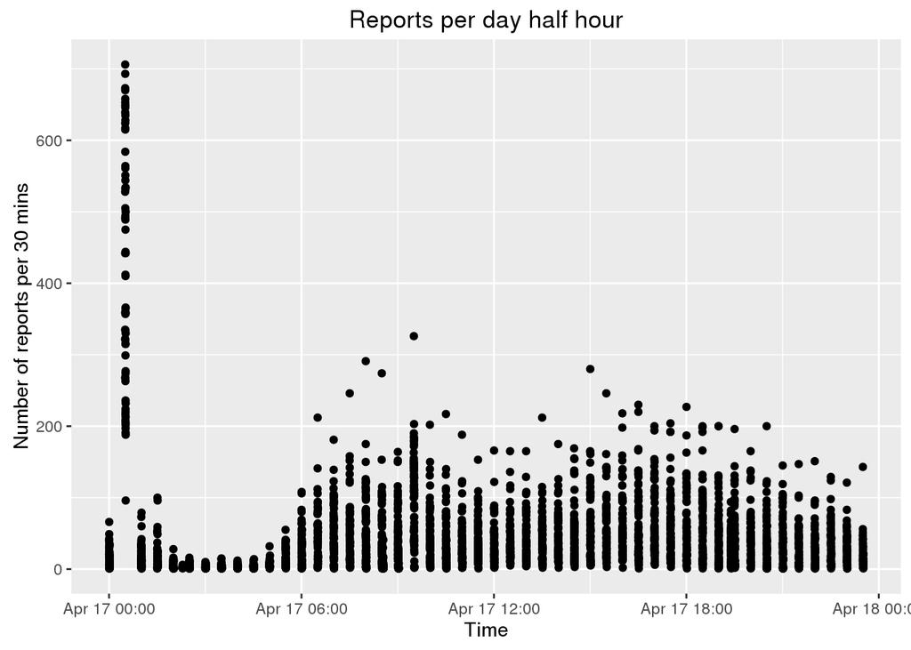

```r
data %>% separate(crawl_date, into=c("crawl_date_tmp","crawl_time"), sep =" ") %>% mutate(crawl_time=as.POSIXct(strptime(crawl_time, format="%H:%M:%S"))) %>% group_by(crawl_time) %>% summarize(c=length(rd.rp.cmid)) %>% ggplot + geom_point(aes(x=crawl_time, y=c)) + labs(title="Reports per day half hour", x="Time", y="Number of reports per 30 mins")
```

The crawling usually takes some time, that’s why we have a lot of values on the x-axis. To have a better plot let’s round it to the nearest half an hour.

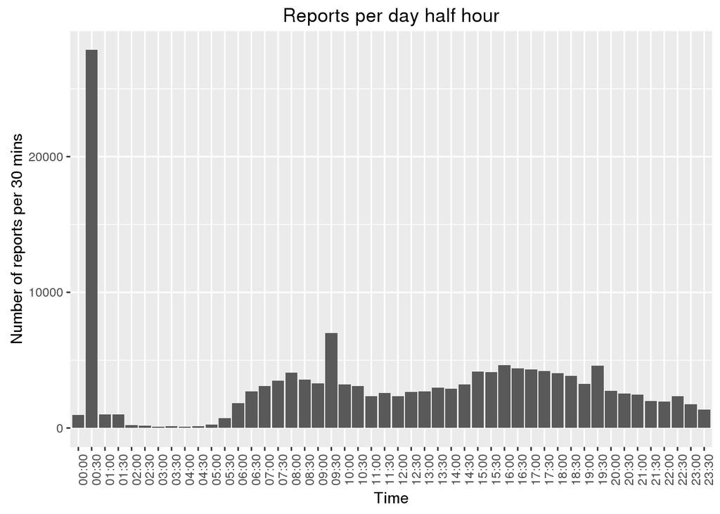

```r
round_time <- function(time, mins){
  posix_time <- as.POSIXct(strptime(time, format="%H:%M:%S", tz="UTC"))
  as.POSIXct(strptime("1970-01-01", "%Y-%m-%d", tz="UTC") + round(as.numeric(posix_time)/(mins*60))*(mins*60))
}

data %>% separate(crawl_date, into=c("crawl_date","crawl_time"), sep =" ") %>% mutate(crawl_time=format(round_time(crawl_time,30), "%H:%M")) %>% group_by(crawl_time) %>% summarize(c=length(rd.rp.cmid)) %>% ggplot(aes(x=crawl_time, y=c)) + geom_bar(stat='identity') + theme(axis.text.x = element_text(angle = 90, hjust = 1)) + labs(title="Reports per day half hour", x="Time", y="Number of reports per 30 mins")
```

The peak at 00:30 seems a bit suspicious. Let’s investigate it more.

```r
data$rd.rp.hr %>% unique
```

```
##  [1]  18  20  22  23  28  24  30  10  12  14  16   2   4   6   7   9  29
## [18]  31   1   3   5   8  11  13  15  17  27  21  19   0  36  33  35  25
## [35]  37  52  32  34  42  44  46  47  49  51  53  26  38  39  40  48  54
## [52]  41  43  61  64  45  60  62  66  68  69  70  72  74  56  57  58  59
## [69]  73  50  71  76  80  78  81  82  83  85  87  75  86  63  55  65  67
## [86] 139  89
```

Seeing this, now we are sure that it’s the number of hours ago the report was created relative to the crawl time. We should take this into consideration instead of using the crawl time only.

```r
data <- (data %>% mutate(report_date=crawl_date - (rd.rp.hr*60*60) - (rd.rp.mn * 60) ))
```

And we don’t need the old columns anymore

```r
data$rd.rp.hr <- NULL
data$rd.rp.mn <- NULL
data$crawl_date <- NULL
```

### Augmenting City names

Let’s augment our data by the info of whether a certain road is in Alexandria and Cairo. By doing so, we would be able to start doing some comparisons between the two cities. Road ids of Cairo and Alex were fetched and parsed from by2ollak’s HTML and written as CSV in `city_road_id.csv`.

```r
city_road <- read.csv("city_road_id.csv")
cairo_ids <- city_road[city_road$city == "cairo","rd.ri"]
alex_ids <- city_road[city_road$city == "alex","rd.ri"]

data <- (data %>% mutate(city= ifelse(rd.ri %in% cairo_ids, "cairo", ifelse(rd.ri %in% alex_ids, "alex", NA))))

#Manually fix some NAs that are not present in the HTML for some reason
data[data$rd.nm == "Makram 3ebeid;Autostrad To Mostafa ElNa7as",]$city <- "cairo"
data[data$rd.nm == "Gam3et ElDewal St;Sudan St To Sphinx",]$city <- "cairo"
data[data$rd.nm == "Tagamo3",]$city <- "cairo"
data[data$rd.nm == "توتال (برج العرب)",]$city <- "alex"
data[data$rd.nm == "Sa7rawy;Alex To Cairo",]$city <- "alex"
```

### Road Speed Dataset

By manually inspecting the website, you’ll find a special username (@bey2ollakgps) who’s always tweeting in a certain format about the speed between two points. Let’s give it a look.

```r
(data %>% filter(grepl("bey2ollakgps", rd.rp.nm)))$rd.rp.cm %>% head
```

```
## [1] الطريق أخد حوالي [4 ق] ومتوسط سرعته [23 كم/س]
## [2] Overall took [4 min] with average speed [23 km/h]
## [3] الطريق أخد حوالي [6 ق] ومتوسط سرعته [16 كم/س]
## [4] Overall took [2 min] with average speed [50 km/h]
## [5] From [Game3 Abo El3abas] to [ElMansheya] took [2 mins] with average speed [40 km/h]
## [6] From [Game3 Abo El3abas] to [ElMansheya] took [3 mins] with average speed [21 km/h]
## 44716 Levels: ;( :-( :/ :'( :( :(( :(((((((((((((((((((( :) :@ ! !! ... ييجي منه حلاوة بس risky شوية.
```

We can extract those speeds data into a separate dataset for further analysis.

```r
speed_data <- ( data %>%
                 filter(grepl("bey2ollakgps", rd.rp.nm)) %>%
                 select(report_date,rd.nm, city, rd.rp.cm, rd.rp.stid)
              )

OVERALL_TOOK_REGEX <- "Overall took \\[(\\d+) min\\] with average speed \\[(\\d+) km/h\\]"
FROM_TO_REGEX <- "From \\[(.*)\\] to \\[(.*)\\] took \\[(\\d+) mins\\] with average speed \\[(\\d+) km/h\\]"
MN_ELA_REGEX <- "من \\[(.*)\\] إلى \\[(.*)\\] في \\[(\\d+) ق\\] ومتوسط سرعته \\[(\\d+) كم/س\\]"
ELTREE2_5AD_REGEX <- "الطريق أخد حوالي \\[(\\d+) ق\\] ومتوسط سرعته \\[(\\d+) كم/س\\]"
ROAD_REGEX <- "(.*);(.*) To (.*)"

tmp2 <- t(apply(speed_data, 1, function(x){

  tmp <- c(NA,NA,NA,NA)

  comment <- x["rd.rp.cm"]
  road_name <- x["rd.nm"]

  if(grepl(OVERALL_TOOK_REGEX, comment)) {
    tmp[1] <- gsub(ROAD_REGEX, "\\1;\\2", road_name)
    tmp[2] <- gsub(ROAD_REGEX, "\\1;\\3", road_name)
    tmp[3] <- gsub(OVERALL_TOOK_REGEX, "\\1", comment)
    tmp[4] <- gsub(OVERALL_TOOK_REGEX, "\\2", comment)
  }

  if(grepl(ELTREE2_5AD_REGEX, comment)) {
    tmp[1] <- gsub(ROAD_REGEX, "\\1;\\2", road_name)
    tmp[2] <- gsub(ROAD_REGEX, "\\1;\\3", road_name)
    tmp[3] <- gsub(ELTREE2_5AD_REGEX, "\\1", comment)
    tmp[4] <- gsub(ELTREE2_5AD_REGEX, "\\2", comment)
  }

  if(grepl(FROM_TO_REGEX, comment)) {
    tmp[1] <- gsub(FROM_TO_REGEX, "\\1", comment)
    tmp[2] <- gsub(FROM_TO_REGEX, "\\2", comment)
    tmp[3] <- gsub(FROM_TO_REGEX, "\\3", comment)
    tmp[4] <- gsub(FROM_TO_REGEX, "\\4", comment)
  }

  if(grepl(MN_ELA_REGEX, comment)) {
    tmp[1] <- gsub(MN_ELA_REGEX, "\\1", comment)
    tmp[2] <- gsub(MN_ELA_REGEX, "\\2", comment)
    tmp[3] <- gsub(MN_ELA_REGEX, "\\3", comment)
    tmp[4] <- gsub(MN_ELA_REGEX, "\\4", comment)
  }

  tmp
}))

speed_data$from <- tmp2[,1]
speed_data$to <- tmp2[,2]
speed_data$time <- tmp2[,3]
speed_data$speed <- tmp2[,4]

speed_data <- (speed_data %>% mutate(speed=as.integer(speed), time=as.integer(time)))
```

Let’s have a look on our new dataset

```r
speed_data %>% sample_n(7) %>% kable
```

|  | report_date | rd.nm | city | rd.rp.cm | rd.rp.stid | from | to | time | speed |
| --- | --- | --- | --- | --- | --- | --- | --- | --- | --- |
| 307 | 2016-02-07 19:11:03 | Da2ery;Moneeb To Autostrad | cairo | من [مخرج دار السلام] إلى [اوتستراد] في [3 ق] ومتوسط سرعته [75 كم/س] | 10 | مخرج دار السلام | اوتستراد | 3 | 75 |
| 18592 | 2016-02-18 21:32:09 | Haram St.;Giza Sq. To Ahramat | cairo | من [المساحة] إلى [الطالبية] في [3 ق] ومتوسط سرعته [27 كم/س] | 10 | المساحة | الطالبية | 3 | 27 |
| 47981 | 2016-02-19 10:00:25 | Autostrad;City Stars To Kobry 6 October | cairo | من [سيتي ستارز] إلى [مكرم عبيد] في [1 ق] ومتوسط سرعته [38 كم/س] | 10 | سيتي ستارز | مكرم عبيد | 1 | 38 |
| 16589 | 2016-02-09 18:39:40 | Kornich ElNile;Da2ery To AlKasr Al3eny St | cairo | From [Kobry El Malek El Sale7] to [Al Kasr Al 3eny Entrance] took [1 mins] with average speed [38 km/h] | 10 | Kobry El Malek El Sale7 | Al Kasr Al 3eny Entrance | 1 | 38 |
| 4244 | 2016-02-18 00:15:40 | AlKasr Al3eny St.;Kornich ElNile To Midan ElTa7rir | cairo | Overall took [3 min] with average speed [57 km/h] | 2 | AlKasr Al3eny St.;Kornich ElNile | AlKasr Al3eny St.;Midan ElTa7rir | 3 | 57 |
| 8727 | 2016-02-19 17:29:04 | Abukir;Victoria To Sidi Gaber | alex | From [Deeb Mall] to [Esharet Mostafa Kamel] took [1 mins] with average speed [26 km/h] | 10 | Deeb Mall | Esharet Mostafa Kamel | 1 | 26 |
| 51498 | 2016-02-09 07:19:29 | Sa7rawy;Me7war To Pyramids Heights | cairo | الطريق أخد حوالي [2 ق] ومتوسط سرعته [97 كم/س] | 1 | Sa7rawy;Me7war | Sa7rawy;Pyramids Heights | 2 | 97 |

### Augmenting the Gender

I though that the gender may be a useful feature in our data so I got the first name of all the users and wrote a script to query an endpoint that can infer genders. The endpoint returns the estimated gender along with how confident it is from this answer. I selected only genders with high confidence. Then using a code, that’s written in Go, each full name is matched with the longest first name it can and gets its gender. Attempting to do so in R was extremely slow because of Regex, so I implemented it using trie in Go. Let’s add these info to our data.

```r
write.csv(data$rd.rp.fullnm, file="./name_manipulation/names.txt")
```

```bash
# Running the Go augmenter to output the (name,gender) pair
pushd ./name_manipulation
./full_name_gender
popd
```

```
## ~/workspace/csen1061-project1-traffic-data-analysis-grading/MohamedBassem-error/name_manipulation ~/workspace/csen1061-project1-traffic-data-analysis-grading/MohamedBassem-error
## ~/workspace/csen1061-project1-traffic-data-analysis-grading/MohamedBassem-error
```

```r
data$gender <- read.csv(file="./name_manipulation/output.txt")$gender
have_a_gender <- data %>% filter(!is.na(gender) & gender != "")
have_a_gender %>% select(rd.rp.nm, gender) %>% head(10) %>% kable
```

| rd.rp.nm | gender |
| --- | --- |
| Tahany_Eyad | male |
| ShahinazSale791 | female |
| Gad.Badr1998 | male |
| Osama.Zaher | male |
| Same7.Wefe2 | male |
| Shimaa.7amed | female |
| Samir.Ra2fat | male |
| Shahinaz_Basem | female |
| Gad.Rashed92 | male |
| Badr.Seif | male |

```r
nrow(have_a_gender)
```

```
## [1] 52301
```

## Descriptive Analysis

### Terminolgy

In the following analysis, we need a way to quantify how crowded is a certain road. To achieve this we will be using the user’s reports. People’s reports are one of the followings:

```
1 --> 7lawa
2 --> lazez
3 --> mashy
4 --> za7ma
5 --> mfesh 2amal
```

If we get the average of those values at a certain point of time we can estimate how crowded a road is. The higher this value, the more crowded the road is. Throughout this document, this metric is called “Average Status ID” or “Average stid”.

*Note* : Any x-axis that’s labelled “Time”" in the following analysis shows the time of a single day starting from the left by 12am till 12am of the following day.

### When do people usually report ?

```r
data %>% separate(report_date, into=c("report_date","report_time"), sep =" ") %>% mutate(report_time=format(round_time(report_time,30), "%H:%M")) %>% group_by(report_time) %>% summarize(c=length(rd.rp.cmid)) %>% arrange(desc(c)) %>% head %>% kable
```

| report_time | c |
| --- | --- |
| 09:00 | 5786 |
| 17:30 | 5758 |
| 16:30 | 5692 |
| 18:00 | 5419 |
| 08:30 | 5361 |
| 18:30 | 5106 |

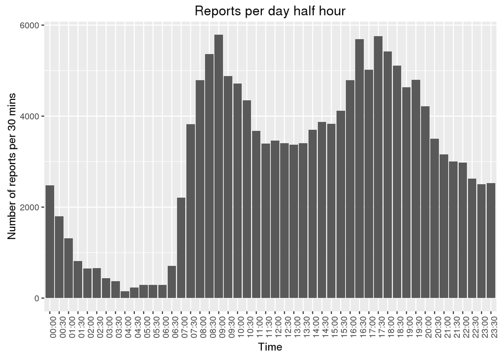

```r
data %>% separate(report_date, into=c("report_date","report_time"), sep =" ") %>% mutate(report_time=format(round_time(report_time,30), "%H:%M")) %>% group_by(report_time) %>% summarize(c=length(rd.rp.cmid)) %>% ggplot(aes(x=report_time, y=c)) + geom_bar(stat='identity') + theme(axis.text.x = element_text(angle = 90, hjust = 1)) + labs(title="Reports per day half hour", x="Time", y="Number of reports per 30 mins")
```

The results shows that people use By2ollak the most when going from home to work (08:30am - 09:00am) and back to home (04:30pm - 06:00pm). Also notice that the period between (03:00am - 06:00am) is the quietest.

We can plot the distribution of reports against the week day.

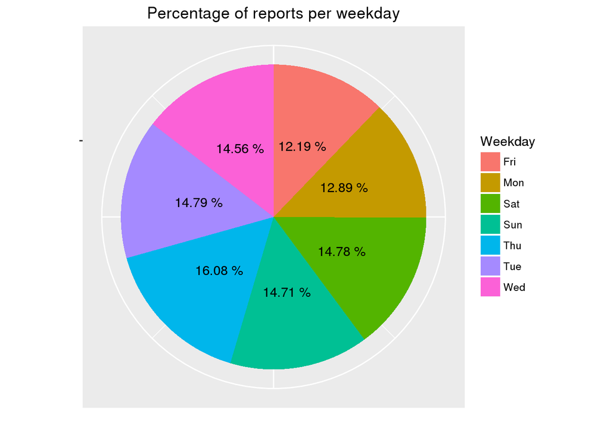

```r
data %>% mutate(report_date=format(report_date, "%a")) %>% group_by(report_date) %>% summarize(c=length(rd.rp.cmid)) %>% mutate(c=(c/sum(c)*100)) %>% mutate(pos = cumsum(c)- c/2) %>% ggplot(aes(x="", y=c, fill=factor(report_date), leg)) + geom_bar(width=1,stat='identity') + geom_text(aes(x="", y=pos, label=paste(format(round(c,2),nsmall=2), "%"))) + coord_polar(theta = "y") + theme(axis.text.x = element_blank()) + labs(title="Percentage of reports per weekday", y="", x="") + scale_fill_discrete(name="Weekday")
```

Report day distribution isn’t really significant as all the days are close to each other. The only significant thing is that Thursday is the highest with a margin probably as it’s the weekend.

If we plot the number of reports segmented by the week day, you’ll notice that the two peaks pattern we talked about earlier ( The work thing ) not there for weekends ( Friday and Saturday ).

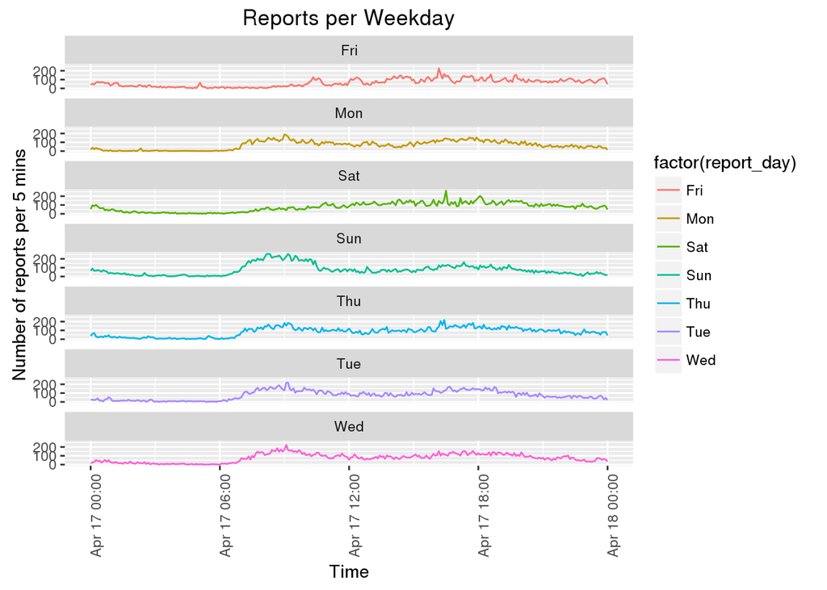

```r
data %>% mutate(new_rep_date=report_date) %>% separate(new_rep_date, into=c("report_date_1","report_time"), sep =" ") %>% mutate(report_time=round_time(report_time,5), report_day=format(report_date, "%a")) %>% group_by(report_day, report_time) %>% summarize(c=length(rd.rp.cmid)) %>% ggplot(aes(x=report_time, y=c, color=factor(report_day))) + geom_line() + theme(axis.text.x = element_text(angle = 90, hjust = 1)) + facet_wrap(~report_day, nrow=7) + labs(title="Reports per Weekday", x="Time", y="Number of reports per 5 mins" )
```

### What are the roads that gets the most reports ?

Let’s plot the top 20 roads that get reports along with the type of reports that they get.

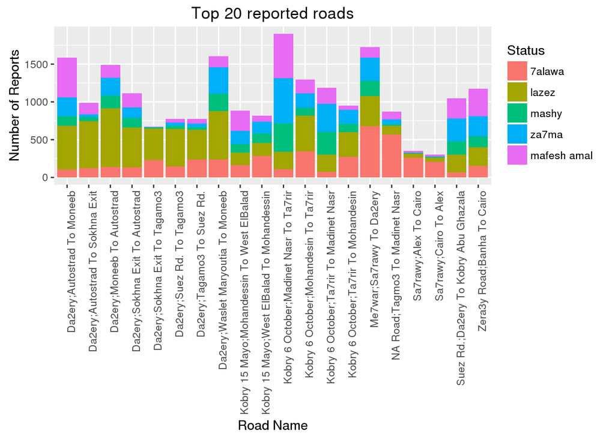

```r
highest_rp_roads <- (data %>% group_by(rd.nm) %>% summarize(c=length(rd.rp.cmid)) %>% arrange(desc(c)) %>% head(20))$rd.nm

data_to_plot <- (data %>% filter(rd.nm %in% highest_rp_roads) %>% filter(rd.rp.stid < 6) %>% group_by(rd.nm, rd.rp.stid) %>% summarize(c=length(rd.rp.cmid)))

stid_mapping <- c("7alawa","lazez","mashy","za7ma","mafesh amal","so2al","5atar","7adsa","3otl","m3loma")

stid_reports <- c("7alawa","lazez","mashy","za7ma","mafesh amal")

(data_to_plot %>% ggplot(aes(x=rd.nm, y=c, fill=factor(rd.rp.stid)))) + geom_bar(stat="identity") + theme(axis.text.x = element_text(angle = 90, hjust = 1)) + scale_fill_discrete(labels=stid_reports, name="Status") + labs(title="Top 20 reported roads", x="Road Name", y="Number of Reports")
```

### A random road : “Me7war: Sa7rawy To Da2ery”

Is the congestion on El Me7war from Sa7rawy to Da2ery affected by the rush hours ?

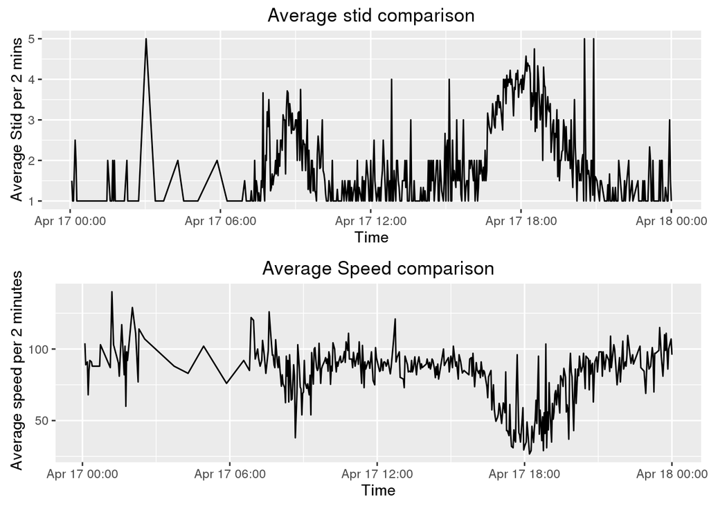

```r
sa7rawy_da2ery <- data %>% filter(rd.nm == "Me7war;Sa7rawy To Da2ery")
sa7rawy_da2ery_speed <- speed_data %>% filter(from == "Me7war;Sa7rawy" & to == "Me7war;Da2ery")

p1 <- sa7rawy_da2ery %>% filter(!is.na(rd.rp.stid) & rd.rp.stid < 6) %>% separate(report_date, into=c("report_date","report_time"), sep =" ") %>% mutate(report_time=round_time(report_time,2)) %>% group_by(report_time) %>% summarize(c= mean(rd.rp.stid)) %>% ggplot(aes(x=report_time, y=c)) + geom_line() + labs(title="Average stid comparison", x="Time", y="Average Stid per 2 mins")

p2 <- sa7rawy_da2ery_speed %>% separate(report_date, into=c("report_date","report_time"), sep =" ") %>% mutate(report_time=round_time(report_time,2)) %>% group_by(report_time) %>% summarize(c= mean(speed)) %>% ggplot(aes(x=report_time, y=c)) + geom_line() + labs(title="Average Speed comparison", x="Time", y=" Average speed per 2 minutes")

multiplot(p1,p2)
```

Yes! The two peaks of the rush hour are reflected on this plot, where it experiences a slowdown and an increase of the average stid.

The average speed of this road and its standard deviation are

```r
sd_mean <- sa7rawy_da2ery_speed$speed %>% mean
sd_sd <- sa7rawy_da2ery_speed$speed %>% sd
sd_n <- sa7rawy_da2ery_speed %>% nrow

sd_mean
```

```
## [1] 80.27379
```

```r
sd_sd
```

```
## [1] 20.93089
```

```r
sd_n
```

```
## [1] 683
```

```r
error <- qnorm(0.975)*sd_sd/sqrt(sd_n)
left <- sd_mean-error
right <- sd_mean+error
```

```r
paste(left, right)
```

```
## [1] "78.7040600304568 81.8435241569517"
```

```r
rm(sd_mean, sd_sd, sd_n, error, left,right)
```

### Cairo Vs. Alex

Let’s plot the percentage of reports in cairo compared to alex.

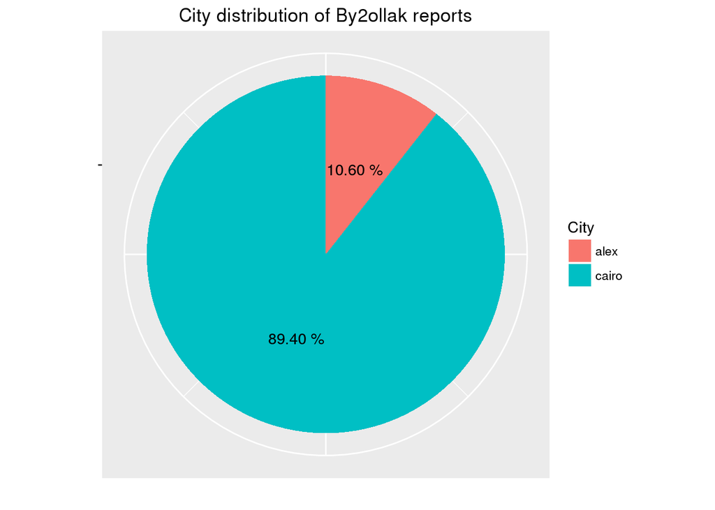

```r
data %>% group_by(city) %>% summarize(c=length(rd.rp.cmid)) %>% mutate(c=(c/sum(c)*100)) %>% mutate(pos = cumsum(c)- c/2) %>% ggplot(aes(x="", y=c, fill=factor(city))) + geom_bar(width=1,stat='identity') + geom_text(aes(x="", y=pos, label=paste(format(round(c,2),nsmall=2), "%"))) + coord_polar(theta = "y") + theme(axis.text.x = element_blank()) + labs(title="City distribution of By2ollak reports", x="", y="") + scale_fill_discrete(name="City")
```

It seems like the number of people reporting in Cairo is much more than those who report in Alex.

Let’s plot the number of reports in both cities against the time

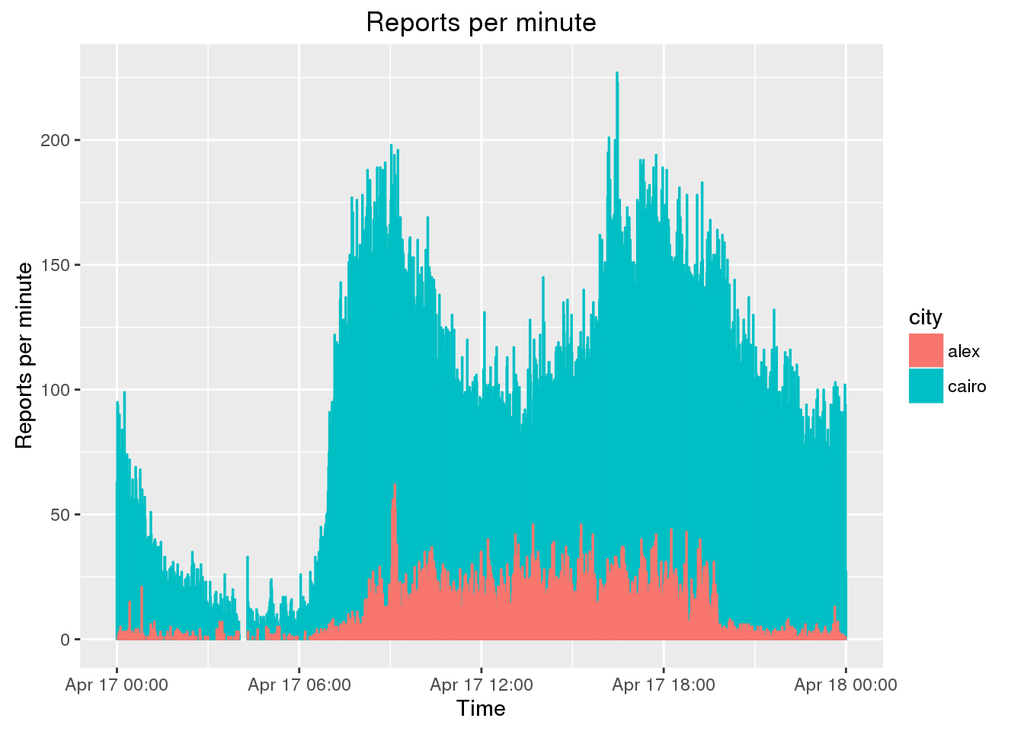

```r
tmp_data <- data %>% separate(report_date, into=c("report_date","report_time"), sep =" ") %>% mutate(report_time=round_time(report_time,1)) %>% group_by(report_time,city) %>% summarize(c= length(rd.rp.stid)) %>% ungroup

tmp_data_cairo <- tmp_data %>% filter(city == "cairo")
tmp_data_alex <- tmp_data %>% filter(city == "alex")

ggplot() + geom_bar(data=tmp_data_cairo, aes(x=report_time,y=c, fill=city, color=city), stat="identity") + geom_bar(data=tmp_data_alex, aes(x=report_time,y=c, fill=city, color=city),stat="identity") + labs(title="Reports per minute", x="Time", y="Reports per minute")
```

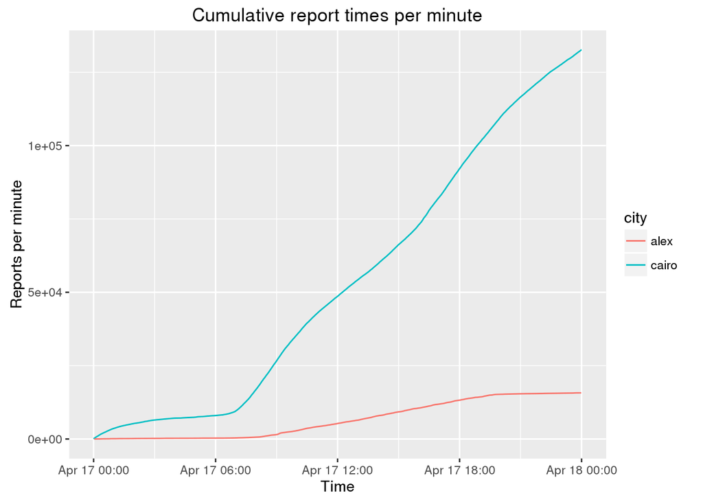

```r
tmp_data <- data %>% separate(report_date, into=c("report_date","report_time"), sep =" ") %>% mutate(report_time=round_time(report_time,1)) %>% group_by(report_time,city) %>% summarize(c= length(rd.rp.stid)) %>% ungroup

tmp_data_cairo <- tmp_data %>% filter(city == "cairo")
tmp_data_alex <- tmp_data %>% filter(city == "alex")

ggplot() + geom_line(data=tmp_data_cairo, aes(x=report_time,y=cumsum(c), color=city)) + geom_line(data=tmp_data_alex, aes(x=report_time,y=cumsum(c), color=city)) + labs(title="Cumulative report times per minute", x="Time", y="Reports per minute")
```

From the two plots, the rush hours in alex isn’t that significant like the one in cairo ( The two peaks ). Does this mean that there isn’t heavy traffic in Alex even in rush hours? Let’s check.

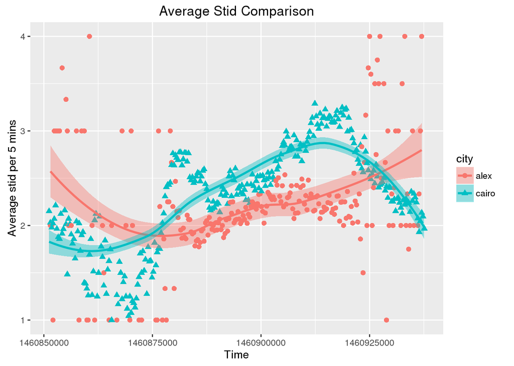

```r
data %>% filter(rd.rp.stid < 6 & !is.na(rd.rp.stid)) %>% separate(report_date, into=c("report_date","report_time"), sep =" ") %>% mutate(report_time=round_time(report_time,5)) %>% group_by(report_time,city) %>% summarize(average_stid= mean(rd.rp.stid)) %>% ggplot(aes(x=as.integer(report_time), y=average_stid, fill=city, color=city, shape=city)) + geom_point(size=2)  + geom_smooth() + labs(title="Average Stid Comparison", x="Time", y="Average stid per 5 mins")
```

Between 9am and 10pm, the average reported status in cairo is always higher than that of Cairo. Alex seems like it’s stable at status Id “2” which is “lazeez”. If so, does this imply that the average speed in alex is higher than that of cairo ?

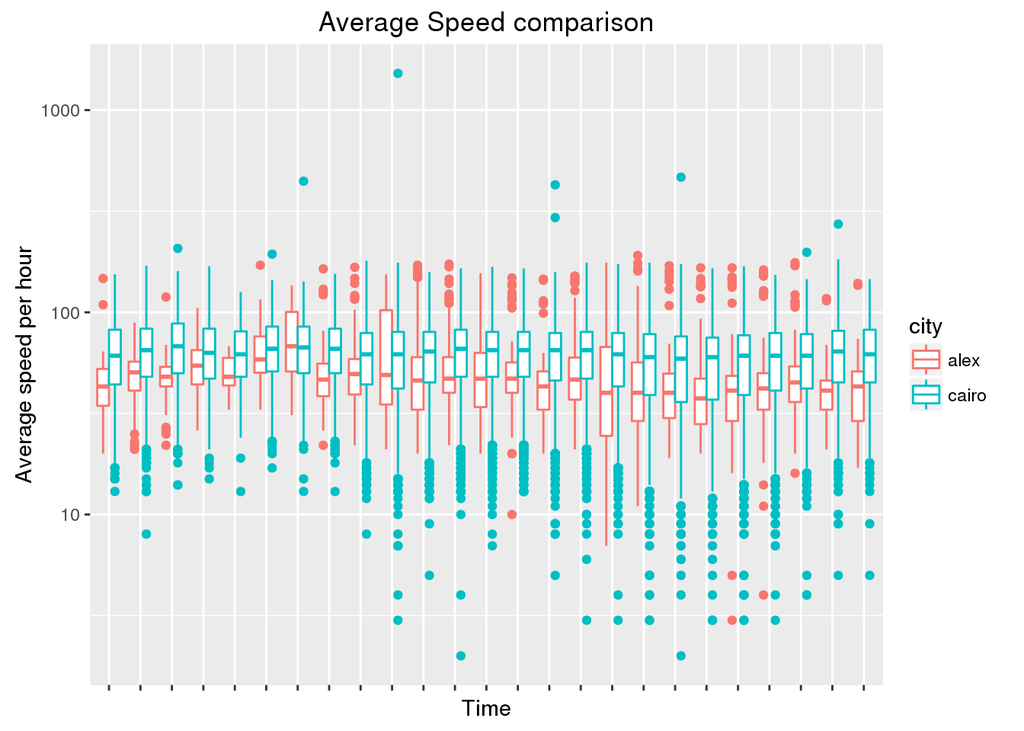

```r
speed_data %>% separate(report_date, into=c("report_date","report_time"), sep =" ") %>% mutate(report_time=round_time(report_time,60)) %>%  ggplot(aes(x=factor(report_time), y=speed, color=city)) + geom_boxplot() + scale_y_log10() + theme(axis.text.x=element_blank()) + labs(title="Average Speed comparison", x="Time", y="Average speed per hour")
```

No. The average speed in Cairo is always higher than Alex.

### Male Vs. Female

First of all, what’s the ratio of female by2ollak users to male users ?

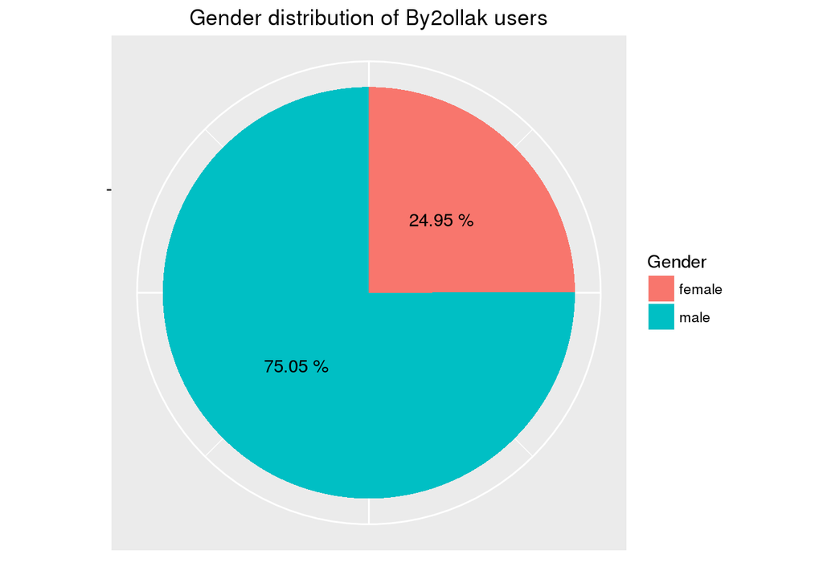

```r
have_a_gender %>% group_by(gender) %>% summarize(c=length(rd.rp.cmid)) %>% mutate(c=(c/sum(c)*100)) %>% mutate(pos = cumsum(c)- c/2) %>% ggplot(aes(x="", y=c, fill=factor(gender))) + geom_bar(width=1,stat='identity') + geom_text(aes(x="", y=pos, label=paste(format(round(c,2),nsmall=2), "%"))) + coord_polar(theta = "y") + theme(axis.text.x = element_blank()) + labs(title="Gender distribution of By2ollak users", x="", y="") + scale_fill_discrete(name="Gender")
```

Males in Egypt usually stay later at night than females, can we prove that from the number of reports of males/females against the time ?

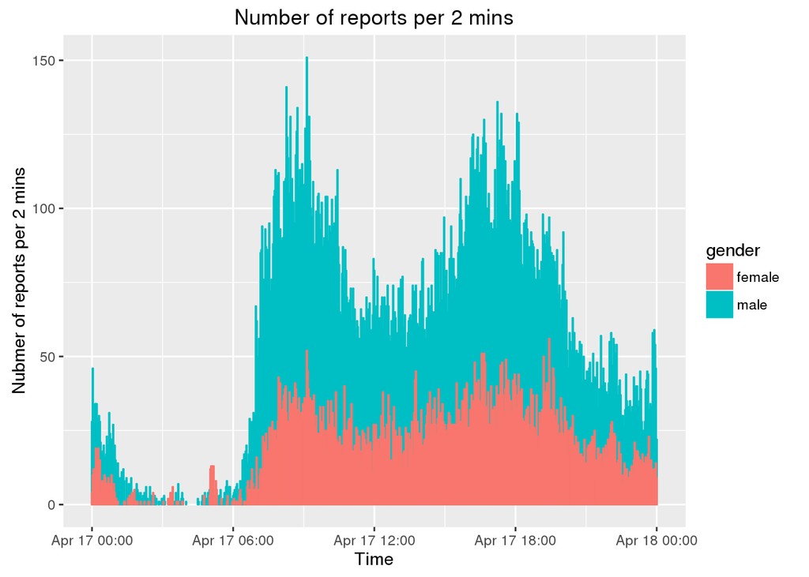

```r
tmp_data <- have_a_gender %>% separate(report_date, into=c("report_date","report_time"), sep =" ") %>% mutate(report_time=round_time(report_time,2)) %>% group_by(report_time,gender) %>% summarize(c= length(rd.rp.cmid)) %>% ungroup

tmp_data_male <- tmp_data %>% filter(gender == "male")
tmp_data_female <- tmp_data %>% filter(gender == "female")

ggplot() + geom_bar(data=tmp_data_male, aes(x=report_time,y=c, fill=gender, color=gender), stat="identity") + geom_bar(data=tmp_data_female, aes(x=report_time,y=c, fill=gender, color=gender),stat="identity") + labs(title="Number of reports per 2 mins", x="Time", y="Nubmer of reports per 2 mins")
```

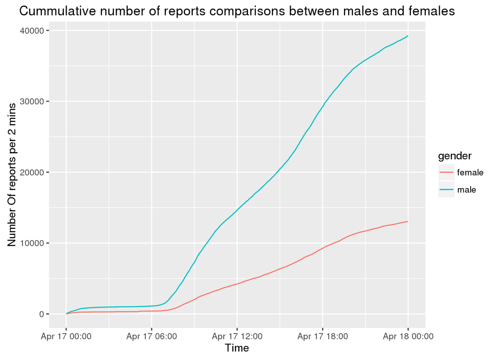

```r
ggplot() + geom_line(data=tmp_data_male, aes(x=report_time,y=cumsum(c), color=gender)) + geom_line(data=tmp_data_female, aes(x=report_time,y=cumsum(c), color=gender)) + labs(title="Cummulative number of reports comparisons between males and females", x= "Time", y= "Number Of reports per 2 mins")
```

No. The plots doesn’t support our assumption.

## Hypotheses

### People tend to report when it’s crowded

My hypothesis here would be that people tend to report more when it’s crowded. To prove this, we’ll need to prove that distribution of the average status ID against the time is equivalent to the distribution of the number of reports against the time. Which means that at a certain point of time, if the number of reports is high, then the average status id should be high.

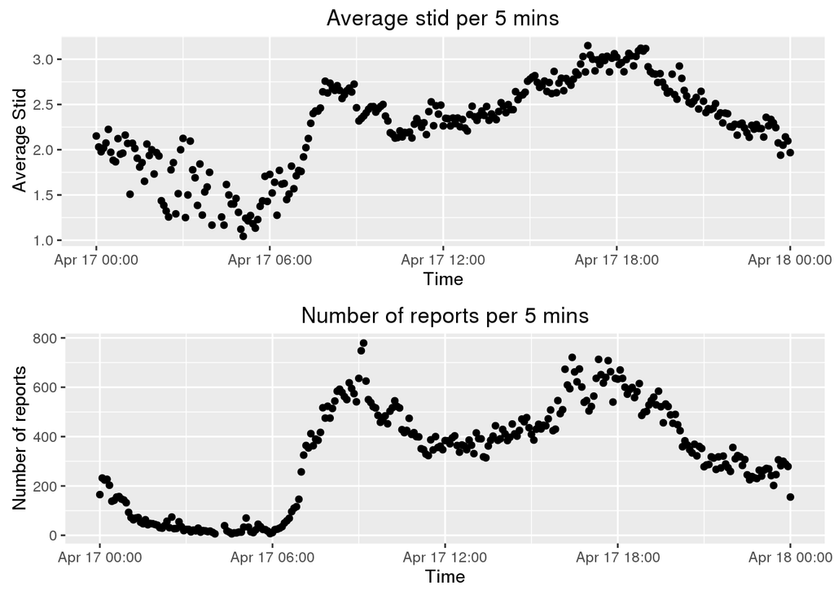

```r
average_stid <- data %>% filter(rd.rp.stid < 6 & !is.na(rd.rp.stid)) %>% separate(report_date, into=c("report_date","report_time"), sep =" ") %>% mutate(report_time=round_time(report_time,5)) %>% group_by(report_time) %>% summarize(average_stid= mean(rd.rp.stid))


reports_per_time <- data %>% filter(rd.rp.stid < 6 & !is.na(rd.rp.stid)) %>% separate(report_date, into=c("report_date","report_time"), sep =" ") %>% mutate(report_time=round_time(report_time,5)) %>% group_by(report_time) %>% summarize(c= length(rd.rp.stid))

p1 <- ggplot(average_stid, aes(x=report_time, y=average_stid)) + geom_point() + labs(title="Average stid per 5 mins", x="Time", y="Average Stid")
p2 <- ggplot(reports_per_time, aes(x=report_time, y=c)) + geom_point() + labs(title="Number of reports per 5 mins", x="Time", y="Number of reports")

multiplot(p1,p2)
```

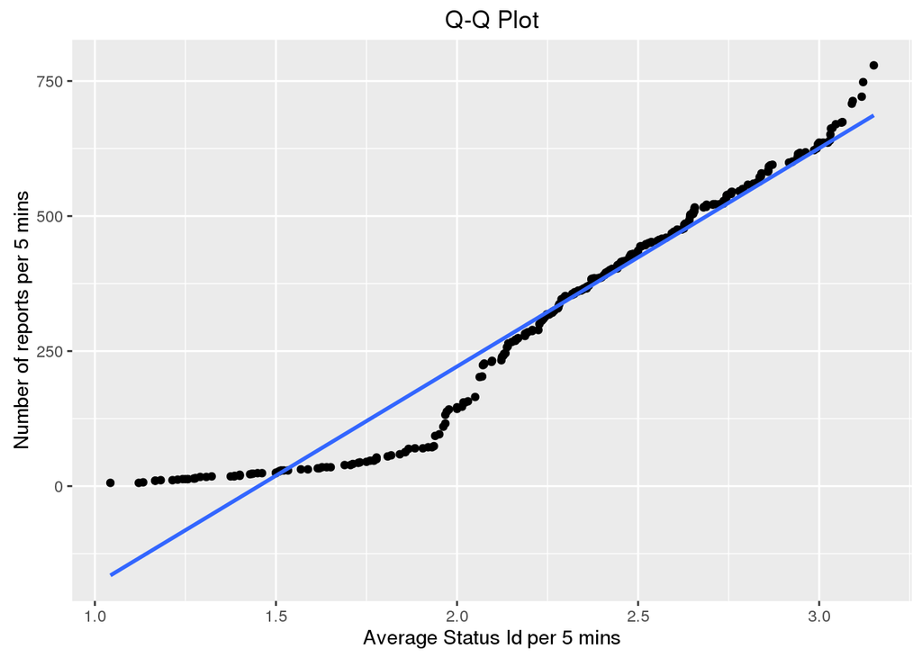

```r
ggplot(NULL,aes(x=sort(average_stid$average_stid), y=sort(reports_per_time$c))) + geom_point() + geom_smooth(method="lm", se=FALSE) + labs(title="Q-Q Plot", y="Number of reports per 5 mins", x="Average Status Id per 5 mins")
```

The qqplot shows that as it gets more crowded ( Increase of average stid ), the number of reports increase. When the the average stid gets greater than 2 (Lazeez), people start reporting about that and then both varibles become directly proportinal.

So back to our hypothesis, it’s proved. After a certain level of crowdedness people start reporting and complaining about that.